# Practical Machine Learning Project

Aneesh Sathe

June 13, 2015

## Background

Using devices such as Jawbone Up, Nike FuelBand, and Fitbit it is now possible to collect a large amount of data about personal activity relatively inexpensively. These type of devices are part of the quantified self movement - a group of enthusiasts who take measurements about themselves regularly to improve their health, to find patterns in their behavior, or because they are tech geeks. One thing that people regularly do is quantify how much of a particular activity they do, but they rarely quantify how well they do it. In this project, your goal will be to use data from accelerometers on the belt, forearm, arm, and dumbell of 6 participants. They were asked to perform barbell lifts correctly and incorrectly in 5 different ways. More information is available from the website here: http://groupware.les.inf.puc-rio.br/har (see the section on the Weight Lifting Exercise Dataset).

## Data

The training data for this project are available here:

https://d396qusza40orc.cloudfront.net/predmachlearn/pml-training.csv

The test data are available here:

https://d396qusza40orc.cloudfront.net/predmachlearn/pml-testing.csv

The data for this project come from this source: http://groupware.les.inf.puc-rio.br/har.

## Steps in generating the model

1. Select Variables
2. Create test and training sets
3. Train model
4. Test accuracy and out of sample error.

```r
library(ggplot2)
library(caret)
```

## Data reading and cleaning

The data was read and all the uimportant variables were removed. The tidy dataset was then partitioned into testing and training sets. Of these the training set was used for training the model.

```r
pro_in_dat=read.csv("pml-training.csv",nrows =2)

keywords=c("X","user_name","min","max","amplitude","window","kurtosis","user","*timestamp*","*skewness*","var","avg","stddev")
strings=colnames(pro_in_dat)

mat=apply(sapply(keywords, grepl, strings, ignore.case=TRUE),1,any)
mat[mat]="NULL"
mat[mat==FALSE]=NA


pro_in_dat=read.csv("pml-training.csv",colClasses = mat)

inTrain <- createDataPartition(y=pro_in_dat$classe,p=0.7, list=FALSE)
training <- pro_in_dat[inTrain,]

testing <- pro_in_dat[-inTrain,]
```

After selecting appropriate columns we further check variables with zero or near zero variance are part of the selection.

```r
nearZeroVar(testing[,1:40],saveMetrics=TRUE)
```

```
##                      freqRatio percentUnique zeroVar   nzv
## roll_belt             1.132296    11.8946474   FALSE FALSE
## pitch_belt            1.175439    22.3789295   FALSE FALSE
## yaw_belt              1.090278    21.5972812   FALSE FALSE
## total_accel_belt      1.059533     0.4418012   FALSE FALSE
## gyros_belt_y          1.171063     1.0535259   FALSE FALSE
## gyros_belt_z          1.099624     2.4468989   FALSE FALSE
## accel_belt_y          1.027140     2.0560748   FALSE FALSE
## accel_belt_z          1.162055     4.3840272   FALSE FALSE
## magnet_belt_y         1.127660     4.2141037   FALSE FALSE
## magnet_belt_z         1.164286     6.2871708   FALSE FALSE
## roll_arm             41.040000    30.2803738   FALSE FALSE
## pitch_arm            73.285714    33.6618522   FALSE FALSE
## yaw_arm              35.379310    33.8827528   FALSE FALSE
## total_accel_arm       1.014440     1.0875106   FALSE FALSE
## gyros_arm_y           1.523810     5.7943925   FALSE FALSE
## gyros_arm_z           1.032468     3.5853866   FALSE FALSE
## accel_arm_y           1.187500     8.4282073   FALSE FALSE
## accel_arm_z           1.076923    11.8946474   FALSE FALSE
## magnet_arm_y          1.346154    13.6958369   FALSE FALSE
## magnet_arm_z          1.028571    19.6261682   FALSE FALSE
## roll_dumbbell         1.078947    90.5862362   FALSE FALSE
## pitch_dumbbell        2.853659    88.5981308   FALSE FALSE
## yaw_dumbbell          1.078947    90.2803738   FALSE FALSE
## total_accel_dumbbell  1.021429     0.6966865   FALSE FALSE
## gyros_dumbbell_y      1.329480     4.0781648   FALSE FALSE
## gyros_dumbbell_z      1.057143     2.9736619   FALSE FALSE
## accel_dumbbell_y      1.178082     7.1028037   FALSE FALSE
## accel_dumbbell_z      1.194444     6.4401020   FALSE FALSE
## magnet_dumbbell_y     1.076923    12.7782498   FALSE FALSE
## magnet_dumbbell_z     1.070175    10.3483432   FALSE FALSE
## roll_forearm         10.548673    20.4418012   FALSE FALSE
## pitch_forearm        56.714286    30.6881903   FALSE FALSE
## yaw_forearm          14.524390    20.2718777   FALSE FALSE
## total_accel_forearm   1.024814     1.0875106   FALSE FALSE
## gyros_forearm_y       1.181818    11.2149533   FALSE FALSE
## gyros_forearm_z       1.061224     4.1631266   FALSE FALSE
## accel_forearm_y       1.344828    15.5480034   FALSE FALSE
## accel_forearm_z       1.074074     8.4451997   FALSE FALSE
## magnet_forearm_y      1.178571    26.6949873   FALSE FALSE
## magnet_forearm_z      1.000000    22.9736619   FALSE FALSE
```

None of the variables selected have zero/near-zero variance. We apply random forest fitting.

```r
modFit=randomForest(classe~.,data=training, ntree=500)
```

# Validation

## Accuracy of training set

```r
pred_tr=predict(modFit,training[,1:40])
confusionMatrix(pred_tr,training$classe)
```

```
## Confusion Matrix and Statistics
##
##           Reference
## Prediction    A    B    C    D    E
##          A 3906    1    0    0    0
##          B    0 2657    4    0    0
##          C    0    0 2391    3    0
##          D    0    0    1 2249    0
##          E    0    0    0    0 2525
##
## Overall Statistics
##
##                Accuracy : 0.9993
##                  95% CI : (0.9988, 0.9997)
##     No Information Rate : 0.2843
##     P-Value [Acc > NIR] : < 2.2e-16
##
##                   Kappa : 0.9992
##  Mcnemar's Test P-Value : NA
##
## Statistics by Class:
##
##                      Class: A Class: B Class: C Class: D Class: E
## Sensitivity            1.0000   0.9996   0.9979   0.9987   1.0000
## Specificity            0.9999   0.9996   0.9997   0.9999   1.0000
## Pos Pred Value         0.9997   0.9985   0.9987   0.9996   1.0000
## Neg Pred Value         1.0000   0.9999   0.9996   0.9997   1.0000
## Prevalence             0.2843   0.1935   0.1744   0.1639   0.1838
## Detection Rate         0.2843   0.1934   0.1741   0.1637   0.1838
## Detection Prevalence   0.2844   0.1937   0.1743   0.1638   0.1838
## Balanced Accuracy      0.9999   0.9996   0.9988   0.9993   1.0000
```

As the accuracy here is 1, there is a fear that there might be overfitting.

## Measuring out of sample error

Next we measure the accuracy of the test set.

```r
pred_out=predict(modFit,testing[,1:40])
confusionMatrix(pred_out,testing$classe)
```

```
## Confusion Matrix and Statistics
##
##           Reference
## Prediction    A    B    C    D    E
##          A 1674    2    0    0    0
##          B    0 1137    2    0    0
##          C    0    0 1022    3    0
##          D    0    0    2  960    2
##          E    0    0    0    1 1080
##
## Overall Statistics
##
##                Accuracy : 0.998
##                  95% CI : (0.9964, 0.9989)
##     No Information Rate : 0.2845
##     P-Value [Acc > NIR] : < 2.2e-16
##
##                   Kappa : 0.9974
##  Mcnemar's Test P-Value : NA
##
## Statistics by Class:
##
##                      Class: A Class: B Class: C Class: D Class: E
## Sensitivity            1.0000   0.9982   0.9961   0.9959   0.9982
## Specificity            0.9995   0.9996   0.9994   0.9992   0.9998
## Pos Pred Value         0.9988   0.9982   0.9971   0.9959   0.9991
## Neg Pred Value         1.0000   0.9996   0.9992   0.9992   0.9996
## Prevalence             0.2845   0.1935   0.1743   0.1638   0.1839
## Detection Rate         0.2845   0.1932   0.1737   0.1631   0.1835
## Detection Prevalence   0.2848   0.1935   0.1742   0.1638   0.1837
## Balanced Accuracy      0.9998   0.9989   0.9977   0.9975   0.9990
```

Just to see which of the variables were the most important in this model we use the varImpPlot() function.

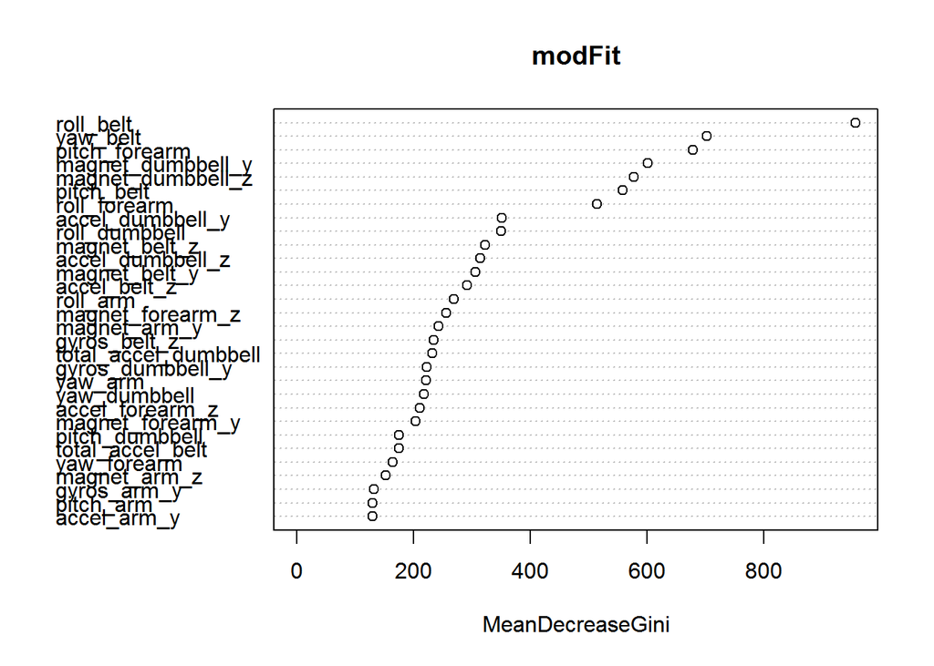

```r
varImpPlot(modFit)
```

As the plot shows the roll_belt variable is quite important.

## Conclusion

The generated model can thus be used on external data.

```r
cs_testing=read.csv("pml-testing.csv",colClasses = mat)
cs_pred_out=predict(modFit,cs_testing[,1:40])
cs_pred_out
```

```
##  1  2  3  4  5  6  7  8  9 10 11 12 13 14 15 16 17 18 19 20
##  B  A  B  A  A  E  D  B  A  A  B  C  B  A  E  E  A  B  B  B
## Levels: A B C D E
```

The answers generated are then submitted to Coursera by generating the files using the provided function below.

```r
pml_write_files = function(x){
        n = length(x)
        for(i in 1:n){
                filename = paste0("problem_id_",i,".txt")
                write.table(x[i],file=filename,quote=FALSE,row.names=FALSE,col.names=FALSE)
        }
}
```